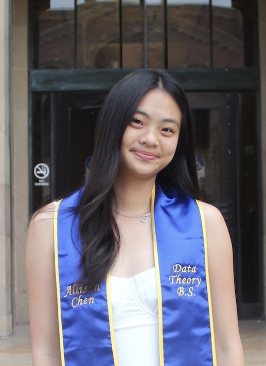

# Allison Chen

## About Me

Hi everyone! I am a first-year ScM Biostatistics student at the Johns Hopkins Bloomberg School of Public Health.I received my Bachelor’s of Science from UCLA with a major in Data Theory and a minor in Data Science Engineering.

During my undergraduate studies, I was a Biostatisitics Research Assistant at the Children’s Hospital of Philadelphia, studying glomerular disease biomarkers. I have also worked as a Data Science Intern at Warner Music Group during my senior year. I am interested in survival analysis, high-dimensional data, and causal inference studies, but I am also open to exploring other fields and intersections of Biostatistics.

## Education

**Johns Hopkins Bloomberg School of Public Health** | Aug 2026 - Expected May 2028  
*ScM in Biostatistics*

**University of California, Los Angeles** | Sep 2022 - Jun 2026  
*BS in Data Theory & Minor in Data Science Engineering*

## Research Experience

**Children’s Hospital of Philadelphia** | Jun 2024 - Jun 2025

**The Bickart Lab at David Geffen School of Medicine at UCLA** | Feb 2024 - Jun 2024

## Interests

Taekwondo (Third Dan Black Belt, Prev. UCLA Taekwondo Assistant Coach)  
Video Editing  
Journaling